## Machine Learning Models - Course Project

### Background

Using devices such as Jawbone Up, Nike FuelBand, and Fitbit it is now possible to collect a large amount of data about personal activity relatively inexpensively. These type of devices are part of the quantified self movement - a group of enthusiasts who take measurements about themselves regularly to improve their health, to find patterns in their behavior, or because they are tech geeks. One thing that people regularly do is quantify how much of a particular activity they do, but they rarely quantify how well they do it. In this project, your goal will be to use data from accelerometers on the belt, forearm, arm, and dumbell of 6 participants. They were asked to perform barbell lifts correctly and incorrectly in 5 different ways. More information is available from the website here: http://groupware.les.inf.puc-rio.br/har (see the section on the Weight Lifting Exercise Dataset).

### Analysis of Human Activity Reconition (HAR)

HAR has emerged as a key research area in the last years and is gaining increasing attention by the pervasive computing research community.

The goal of this project is to predict the manner in which they did the exercise. This is the “classe” variable in the training set. You may use any of the other variables to predict with. You should create a report describing how you built your model, how you used cross validation, what you think the expected out of sample error is, and why you made the choices you did. You will also use your prediction model to predict 20 different test cases.

### Preliminary setup

```r
library(knitr)
library(markdown)
library(caret)
library(randomForest)
setwd("c:/Users/Alan/Documents/Data Science Course (Coursera)/Machine Learning/Project")
pmlTrain <- read.csv("pml-training.csv", na.strings = c("NA", ""), header = TRUE)
pmlTest <- read.csv("pml-testing.csv", na.strings = c("NA", ""), header = TRUE)
```

### Exploratory data analysis

```r
dim(pmlTrain)
```

```
## [1] 19622   160
```

```r
summary(pmlTrain$classe)
```

```
##    A    B    C    D    E
## 5580 3797 3422 3216 3607
```

#### Variable Reduction

There are currently 159 variables (not counting label) available to use for training the model. Let’s pare that down a bit.

```r
# First remove variables with missing values
ColSums <- colSums(!is.na(pmlTrain[,-ncol(pmlTrain)]))
head(ColSums)
```

```
##                    X            user_name raw_timestamp_part_1
##                19622                19622                19622
## raw_timestamp_part_2       cvtd_timestamp           new_window
##                19622                19622                19622
```

```r
sum(colSums(!is.na(pmlTrain[,-ncol(pmlTrain)]))>=0.7*nrow(pmlTrain))
```

```
## [1] 59
```

```r
validCol <- colSums(!is.na(pmlTrain[,-ncol(pmlTrain)]))>=0.7*nrow(pmlTrain)
pmlTrain <- pmlTrain[,validCol]
dim(pmlTrain)
```

```
## [1] 19622    60
```

```r
#Another way to remove missing value variables
#naVars = sapply(pmlTrain, function(x) {sum(is.na(x))})
#table(naVars)
#badVars = names(naVars[naVars==13460])
#pmlTrain = pmlTrain[, !names(pmlTrain) %in% badVars]
```

The following transformations were used to clean the data: Transformation 1: Cleaning NearZeroVariance Variables Run this code to view possible NZV Variables:

Look for predictors that have one or few unique values relative to # of samples

```r
myDataNZV <- nearZeroVar(pmlTrain, saveMetrics=TRUE)
myDataNZV[myDataNZV[,"zeroVar"] > 0, ]                      # find zero variance predictors
```

```
## [1] freqRatio     percentUnique zeroVar       nzv
## <0 rows> (or 0-length row.names)
```

```r
myDataNZV[myDataNZV[,"zeroVar"] + myDataNZV[,"nzv"] > 0, ]  # find near zero variance predictors + zero variance predictors
```

```
##            freqRatio percentUnique zeroVar  nzv
## new_window     47.33       0.01019   FALSE TRUE
```

```r
myDataNZV <- nearZeroVar(pmlTrain)
pmlTrain <- pmlTrain[-myDataNZV]
dim(pmlTrain)
```

```
## [1] 19622    59
```

```r
# Remove the "ID" Variable
pmlTrain <- pmlTrain[,-1]

# number of the columns with numeric values
sum(sapply(pmlTrain, is.numeric))
```

```
## [1] 55
```

```r
# Variables with high correlation
corrMatrix <- cor(na.omit(pmlTrain[sapply(pmlTrain, is.numeric)]))
dim(corrMatrix)
```

```
## [1] 55 55
```

```r
# Choose a cut-off of 90% to keep
highCorr <- findCorrelation(corrMatrix, cutoff = .90, verbose = F)

# Final Training set
pmlTrain <- pmlTrain[,-highCorr]
dim(pmlTrain)
```

```
## [1] 19622    51
```

#### Apply same transformation to separate test dataset

```r
pmlTest <- pmlTest[,validCol]
pmlTest <- pmlTest[,-myDataNZV]
pmlTest <- pmlTest[,-1]
pmlTest <- pmlTest[,-highCorr]
dim(pmlTest)
```

```
## [1] 20 51
```

### Analysis

#### Subsetting the original dataset

Okay, now that we’ve done all the transformations, now let’s break up this dataset into a “train” and “test” set

```r
set.seed(3)

inTrain <- createDataPartition(y=pmlTrain$classe, p=0.7, list=FALSE)
training <- pmlTrain[inTrain,]
testing <- pmlTrain[-inTrain,]
dim(training)
```

```
## [1] 13737    51
```

### Model Building and Fitting

Random forests build lots of bushy trees, and then average them to reduce the variance. In random forests, there is no need for cross-validation or a separate test set to get an unbiased estimate of the test set error. It is estimated internally, during the execution. So, we proced with the training the model (Random Forest) with the training data set.

```r
fit <- randomForest(classe ~ .,data=training,importance=TRUE)
fit
```

```
##
## Call:
##  randomForest(formula = classe ~ ., data = training, importance = TRUE)
##                Type of random forest: classification
##                      Number of trees: 500
## No. of variables tried at each split: 7
##
##         OOB estimate of  error rate: 0.15%
## Confusion matrix:
##      A    B    C    D    E class.error
## A 3906    0    0    0    0   0.0000000
## B    2 2656    0    0    0   0.0007524
## C    0    3 2391    2    0   0.0020868
## D    0    0    8 2243    1   0.0039964
## E    0    0    0    4 2521   0.0015842
```

```r
# Alternative method for performing the training and performing model evalution, also saves the object
#model = train(classe~., method="rf", data=training)
#saveRDS(model, "rfmodel.RDS")
#model = readRDS("rfmodel.RDS")
#mean(predict(model, testing) == testing$classe) * 100
```

Okay, now let’s look at variable importance, given the fact that the # of variables tried at each split = 7

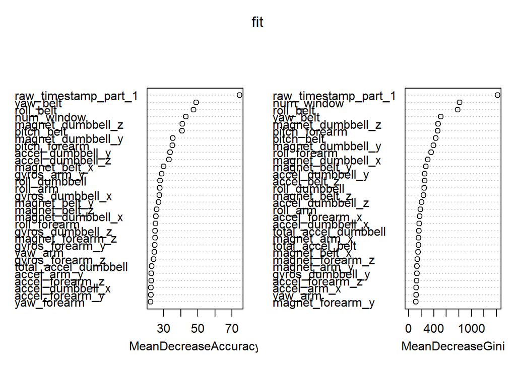

```r
varImpPlot(fit)
```

### Out of Sample Accuracy

```r
confusionMatrix(predict(fit,newdata=testing[,-ncol(testing)]),testing$classe)
```

```
## Confusion Matrix and Statistics
##
##           Reference
## Prediction    A    B    C    D    E
##          A 1674    6    0    0    0
##          B    0 1133    4    0    0
##          C    0    0 1022    3    0
##          D    0    0    0  960    4
##          E    0    0    0    1 1078
##
## Overall Statistics
##
##                Accuracy : 0.997
##                  95% CI : (0.995, 0.998)
##     No Information Rate : 0.284
##     P-Value [Acc > NIR] : <2e-16
##
##                   Kappa : 0.996
##  Mcnemar's Test P-Value : NA
##
## Statistics by Class:
##
##                      Class: A Class: B Class: C Class: D Class: E
## Sensitivity             1.000    0.995    0.996    0.996    0.996
## Specificity             0.999    0.999    0.999    0.999    1.000
## Pos Pred Value          0.996    0.996    0.997    0.996    0.999
## Neg Pred Value          1.000    0.999    0.999    0.999    0.999
## Prevalence              0.284    0.194    0.174    0.164    0.184
## Detection Rate          0.284    0.193    0.174    0.163    0.183
## Detection Prevalence    0.285    0.193    0.174    0.164    0.183
## Balanced Accuracy       0.999    0.997    0.998    0.998    0.998
```

Accuracy is “99.69%”

### Final Prediction!

Finally, let’s apply this same model to the separate test dataset

```r
predictions <- predict(fit,newdata=pmlTest)
predictions
```

```
##  1  2  3  4  5  6  7  8  9 10 11 12 13 14 15 16 17 18 19 20
##  B  A  B  A  A  E  D  B  A  A  B  C  B  A  E  E  A  B  B  B
## Levels: A B C D E
```